# Data Viz

Qahhar

2023-12-30

```r
## load packages
library(janitor)
```

```r
library(ggplot2)
library(dplyr)
library(lubridate)
library(zoo)
library(forcats)
library(ggthemes)
library(knitr)
```

# Part 1: Exploratory Data Analysis

The data we’ll be using for this part of the project were downloaded from [kaggle](https://www.kaggle.com/aaronschlegel/seattle-pet-licenses/data), and include information about “pet licenses issued by the Seattle Animal Shelter between 2005 and early 2017.” We’ll be exploring these data and generating a few exploratory plots in the first part of the project.

## The Data

First, we’ll read the data in from our `data/raw_data` directory.

```r
# pets <- read.csv("/cloud/project/data/raw_data/seattle_pet_licenses.csv",
# stringsAsFactors = FALSE)

pets <- read.csv("/cloud/project/data/raw_data/seattle_pet_licenses.csv")

head(pets, n = 3)
```

```
##   animal_s_name      license_issue_date license_number
## 1          Ozzy 2005-03-29T00:00:00.000         130651
## 2          Jack 2009-12-23T00:00:00.000         898148
## 3        Ginger 2006-01-20T00:00:00.000          29654
##                       primary_breed     secondary_breed species zip_code
## 1 Dachshund, Standard Smooth Haired                         Dog    98104
## 2              Schnauzer, Miniature        Terrier, Rat     Dog    98107
## 3                 Retriever, Golden Retriever, Labrador     Dog    98117
```

It is noticed that a column `licence_issue_date` is not in the right format

```r
pets <- pets %>%
  mutate(license_issue_date = ymd_hms(license_issue_date)) %>%
  mutate(license_issue_date = format(license_issue_date, "%Y-%m-%d")) %>%
  arrange(desc(license_issue_date))

# pets <- pets %>%
#   mutate(date =  lubridate::ymd_hms(license_issue_date),
#          ymd = as.yearmon(pets$date, "%y%m"))

head(pets, n = 3)
```

```
##   animal_s_name license_issue_date license_number      primary_breed
## 1          Foxy         2016-12-31         823671 Domestic Shorthair
## 2         Penny         2016-12-31             NA           Brittany
## 3 Snickerdoodle         2016-12-31         722662 Domestic Shorthair
##   secondary_breed species zip_code
## 1                     Cat    98107
## 2                     Dog    98133
## 3                     Cat    98133
```

## Explore the Data

```r
#Understanding the structure

glimpse(pets)
```

```
## Rows: 66,042
## Columns: 7
## $ animal_s_name      <chr> "Foxy", "Penny", "Snickerdoodle", "Jasper", "Gabbie…
## $ license_issue_date <chr> "2016-12-31", "2016-12-31", "2016-12-31", "2016-12-…
## $ license_number     <int> 823671, NA, 722662, 21434, 723818, NA, NA, 833723, …
## $ primary_breed      <chr> "Domestic Shorthair", "Brittany", "Domestic Shortha…
## $ secondary_breed    <chr> "", "", "", "Retriever, Labrador", "", "", "", "", …
## $ species            <chr> "Cat", "Dog", "Cat", "Dog", "Dog", "Dog", "Dog", "C…
## $ zip_code           <chr> "98107", "98133", "98133", "98136", "98136", "98112…
```

```r
colnames(pets)
```

```
## [1] "animal_s_name"      "license_issue_date" "license_number"
## [4] "primary_breed"      "secondary_breed"    "species"
## [7] "zip_code"
```

```r
# #Summarizing factor/character columns only
# char_cols <- pets %>% select_if(is.character)
# summary(char_cols)
#
# summary(pets$species)
```

- How many pet licenses are included in the dataset?

```r
sum(!is.na(pets$license_number))
```

```
## [1] 43885
```

- How many unique pet names are included in the dataset (animal_s_name)

```r
length(unique(pets$animal_s_name))
```

```
## [1] 15796
```

15796 unique names out of 66042. Find the more common names?

```r
# Use the pipe operator to find the most common names
ten_most_common_names <- pets %>%
  na.omit() %>%
  filter(animal_s_name != "") %>%
  group_by(animal_s_name) %>%
  summarize(count = n()) %>%
  arrange(desc(count)) %>%
  top_n(10)
# Display the result
head(ten_most_common_names, n = 3)
```

```
## # A tibble: 3 × 2
##   animal_s_name count
##   <chr>         <int>
## 1 Lucy            411
## 2 Bella           318
## 3 Charlie         295
```

- How many different species are included in this dataset (species)?

```r
length(unique(pets$species))
```

```
## [1] 3
```

- Which species are included in the dataset?

```r
unique(pets$species)
```

```
## [1] "Cat"       "Dog"       "Livestock"
```

```r
#Count of each unique specie
species_counts <- pets %>%
  group_by(species) %>%
  summarise(count = n())

print(species_counts)
```

```
## # A tibble: 3 × 2
##   species   count
##   <chr>     <int>
## 1 Cat       22915
## 2 Dog       43076
## 3 Livestock    51
```

## Visualize the Data

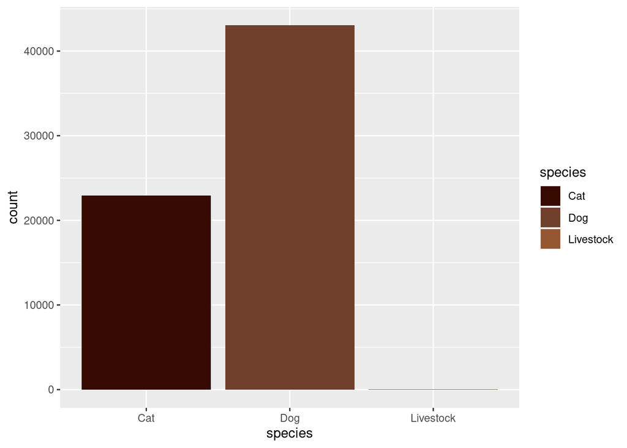

```r
## visual breakdown of how many of each species

colors <- c('#370B01', "#70402C", "#955732")
ggplot(data = pets) +
  geom_bar(aes(x=species, fill = species, fill = species))+
  scale_fill_manual(values = colors)
```

```r
## Table: Most frequent Cat Name
pets %>%
  filter(species == "Cat", animal_s_name != "") %>%
  group_by(animal_s_name) %>%
  summarise(n = n()) %>%
  arrange(-n) %>%
  top_n(n = 10) %>%
  knitr::kable(., caption = "Top 10 Cat Names in Seattle")
```

Top 10 Cat Names in Seattle

| animal_s_name | n |
| --- | --- |
| Lucy | 150 |
| Max | 120 |
| Luna | 119 |
| Bella | 113 |
| Oliver | 108 |
| Charlie | 99 |
| Lily | 93 |
| Jack | 87 |
| Sophie | 81 |
| Shadow | 69 |

```r
#using either arrange(desc(n)) or arrange(-n) will achieve the same result:

# arrange(desc(n)): Sorts the values in descending order based on the column n.
# arrange(-n): Also sorts the values in descending order based on the column n.
```

```r
## Table: Most frequent Dog Name
pets %>%
  filter(species == "Dog", animal_s_name != "") %>%
  group_by(animal_s_name) %>%
  summarise(n = n()) %>%
  arrange(-n) %>%
  top_n(n = 10) %>%
  knitr::kable(., caption = "Top 10 Dog Names in Seattle")
```

Top 10 Dog Names in Seattle

| animal_s_name | n |
| --- | --- |
| Lucy | 416 |
| Charlie | 348 |
| Bella | 338 |
| Buddy | 256 |
| Daisy | 256 |
| Max | 254 |
| Molly | 243 |
| Luna | 242 |
| Lola | 232 |
| Maggie | 226 |

- How the number of licenses recorded has changed over time?

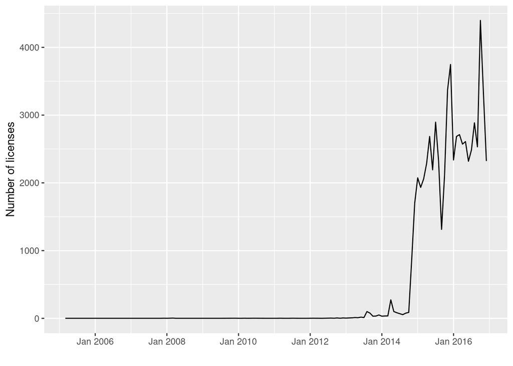

```r
# add date and ym columns
# pets$ym <- as.yearmon(pets$license_issue_date, "%y%m")

pets$ym <- as.yearmon(pets$license_issue_date, "%Y-%m-%d")

# how the number of licenses recorded has changed over time
pets %>%
  group_by(ym) %>%
  ## count number within each group
  summarize(n= n()) %>%
  ggplot(., aes(ym, n)) +
  ## geom name for line chart
  geom_line() +
  scale_x_yearmon() +
  xlab("") +
  ylab("Number of licenses")
```

# Part 2: Explanatory Data Analysis

The data used in this part of the project were dowloaded from [FiveThirtyEight](https://data.fivethirtyeight.com/) - `steak-survey`. They were originally used in the article: [How Americans Like Their Steak](https://fivethirtyeight.com/features/how-americans-like-their-steak/). The goal of this part of the project will be to recreate the data visualization used in this article.

## The Data

The data focus on a question of choice,

Consider the following hypothetical situations - In Lottery A, you have a 50 chance of success with a payout of 100

- In Lottery B you have a 90 chance of success with a payout of 20

Assuming you have 10 to bet, would you play Lottery A or Lottery B.

```r
## read in the data
steak <- read.csv("/cloud/project/data/raw_data/steak-risk-survey.csv") %>%
  ## remove first row which just includes the word "Response" in each column
  slice(2:n())

head(steak, n = 3)
```

```
##   RespondentID
## 1   3237565956
## 2   3234982343
## 3   3234973379
##   Consider.the.following.hypothetical.situations...br.In.Lottery.A..you.have.a.50..chance.of.success..with.a.payout.of..100...br.In.Lottery.B..you.have.a.90..chance.of.success..with.a.payout.of..20...br..br.Assuming.you.have..10.to.bet..would.you.play. ...
## 1                                                                                                                                                                                                                                                      Lottery B
## 2                                                                                                                                                                                                                                                      Lottery A
## 3                                                                                                                                                                                                                                                      Lottery A
##   Do.you.ever.smoke.cigarettes. Do.you.ever.drink.alcohol. Do.you.ever.gamble.
## 1
## 2                            No                        Yes                  No
## 3                            No                        Yes                 Yes
##   Have.you.ever.been.skydiving. Do.you.ever.drive.above.the.speed.limit.
## 1
## 2                            No                                       No
## 3                            No                                      Yes
##   Have.you.ever.cheated.on.your.significant.other. Do.you.eat.steak.
## 1
## 2                                               No               Yes
## 3                                              Yes               Yes
##   How.do.you.like.your.steak.prepared. Gender  Age  Household.Income
## 1
## 2                          Medium rare   Male > 60 $50,000 - $99,999
## 3                                 Rare   Male > 60         $150,000+
##                          Education Location..Census.Region.
## 1
## 2 Some college or Associate degree       East North Central
## 3                  Graduate degree           South Atlantic
```

Column names are lengthy, try changing?

```r
colnames(steak)
```

```
##  [1] "RespondentID"
##  [2] "Consider.the.following.hypothetical.situations...br.In.Lottery.A..you.have.a.50..chance.of.success..with.a.payout.of..100...br.In.Lottery.B..you.have.a.90..chance.of.success..with.a.payout.of..20...br..br.Assuming.you.have..10.to.bet..would.you.play.Lottery.A.or.Lottery.B."
##  [3] "Do.you.ever.smoke.cigarettes."
##  [4] "Do.you.ever.drink.alcohol."
##  [5] "Do.you.ever.gamble."
##  [6] "Have.you.ever.been.skydiving."
##  [7] "Do.you.ever.drive.above.the.speed.limit."
##  [8] "Have.you.ever.cheated.on.your.significant.other."
##  [9] "Do.you.eat.steak."
## [10] "How.do.you.like.your.steak.prepared."
## [11] "Gender"
## [12] "Age"
## [13] "Household.Income"
## [14] "Education"
## [15] "Location..Census.Region."
```

```r
steak %>%
  rename(lottery_choice = Consider.the.following.hypothetical.situations...br.In.Lottery.A..you.have.a.50..chance.of.success..with.a.payout.of..100...br.In.Lottery.B..you.have.a.90..chance.of.success..with.a.payout.of..20...br..br.Assuming.you.have..10.to.bet..would.you.play.Lottery.A.or.Lottery.B.)
```

```
##     RespondentID lottery_choice Do.you.ever.smoke.cigarettes.
## 1     3237565956      Lottery B
## 2     3234982343      Lottery A                            No
## 3     3234973379      Lottery A                            No
## 4     3234972383      Lottery B                           Yes
## 5     3234958833      Lottery B                            No
## 6     3234955240      Lottery A                            No
## 7     3234955097      Lottery A                            No
## 8     3234955010      Lottery A                            No
## 9     3234953052      Lottery A                           Yes
## 10    3234951249      Lottery B                            No
## 11    3234948883      Lottery B                            No
## 12    3234948197      Lottery A                            No
## 13    3234947477      Lottery B                            No
## 14    3234946739      Lottery A                           Yes
```

[output cut: 3291 more lines]

## Explore the Data

- How many people participated in the survey?

```r
nrow(steak)
```

```
## [1] 550
```

- How many people responded “Yes” to the question “Do you eat steak?”

```r
yes_steak <- steak %>%
  filter(Do.you.eat.steak. == 'Yes') %>%
  summarise(count = n())

yes_steak
```

```
##   count
## 1   430
```

How many different (unique) responses were there to the question “How do you like your steak prepared?”

```r
new_steak <- steak %>%
  filter(How.do.you.like.your.steak.prepared. != "")

length(unique(new_steak$How.do.you.like.your.steak.prepared.))
```

```
## [1] 5
```

```r
unique(new_steak$How.do.you.like.your.steak.prepared.)
```

```
## [1] "Medium rare" "Rare"        "Medium"      "Medium Well" "Well"
```

## Wrangle the Data

```r
# Create a new data frame from steak data frame and assign it to the variable `pref`
pref <- steak %>%
  #code below creates a column 'steak_pref' with its values being the unique characters of the How.do.you.like.your.steak.prepared. column from 'steak' being converted to factors
  mutate(steak_pref = factor(How.do.you.like.your.steak.prepared.,
                             levels = c("Well",
                                        "Medium Well",
                                        "Medium",
                                        "Medium rare",
                                        "Rare"))) %>%
  #Filters out the values in the steak_pref column that are notated as ''
  filter(steak_pref != "") %>%
  group_by(steak_pref) %>%
  #Using the summarize function we create a new col 'n' which basically takes the count of individual groups
  summarise(n = n()) %>%
  # Create a new column that creates a ratio of each unique character, by dividing their sum over the total sum
  mutate(ratio = n / sum(n))

ncol(pref)
```

```
## [1] 3
```

## Visualize the Data

[figure not shown]

```r
## generate the plot
p <- ggplot(pref) +
  ## specify you want to generate a bar chart
  geom_bar(aes(x = steak_pref, y = ratio, fill = steak_pref),
                stat = 'identity',
                width = 0.7) +
  ## this adds text labels (you don't have to change anything here)
  geom_text(aes(label = paste0(as.integer(ratio*100),"%"),
                x = steak_pref,
                y = ratio),
            stat= "identity",
            hjust = -0.2,
            size = 5,
            color = "grey40") +
  ## flip coordinates to make horizontal box plot
  coord_flip() +
  ## change the colors of the bars
  scale_fill_manual(values = c("#370B01",
                           "#70402C",
                           "#955732",
                           "#B36153",
                           "#B5413F")) +
  ## change the scale/labels of the steak-wellness variable (x-axis)
  scale_x_discrete(limits = levels(fct_rev(pref$steak_pref)),
                labels = c("Well",
                           "Medium Well" = "Medium-well",
                           "Medium",
                           "Medium rare"="Medium-rare",
                           "Rare")) +
  # change the scale/labels of the percent axis (y-axis)
  scale_y_continuous(labels = scales::percent,
                expand = c(mult = c(0,0),
                           add = c(0,0.035))) +
  ## change the title, subtitle, and caption
  labs(title="'How Do You Like Your Steak Prepared?'",
                subtitle="From a survey of 432 steak-eating Americans",
                caption="FiveThirtyEight: Surveymonkey") +
  ## change the theme (use ggthemes)
  theme_grey() +
  ## fine tune the theme
  theme(axis.text = element_text(size = 14),
                title = element_text(size = 16),
                legend.position="none",
                plot.caption=element_text(size = 12),
                panel.grid.major = element_blank(),
                panel.grid.minor = element_blank(),
                axis.text.x = element_blank()
  )

p
```

## Save the Plot

```r
## save plot to figures/explanatory_figures directory
ggsave(plot = p, filename = '/cloud/project/steak_graph.png', width = 8, height = 4)
```